# Day 1A Activity (Exploratory Data Analysis) - Solutions

# Load Packages

```r
if (!require("tidyverse")) {install.packages("tidyverse"); require("tidyverse")}
if (!require("summarytools")) {install.packages("summarytools"); require("summarytools")}
if (!require("psych")) {install.packages("psych"); require("psych")}
if (!require("psychTools")) {install.packages("psychTools"); require("psychTools")}
if (!require("caret")) {install.packages("caret"); require("caret")}
if (!require("mice")) {install.packages("mice"); require("mice")}
if (!require("VIM")) {install.packages("VIM"); require("VIM")}
```

# Load Data

This activity will use the ‘globalWarm’ dataset from the ‘psychTools’ package, a dataset exploring the relationships between emotions, ideology, and party affiliation as predictors of attitudes towards government action on climate change.

1. Load in the ‘globalWarm’ dataset:

(optional: read a bit about this dataset using ?globalWarm)

```r
data('globalWarm')
```

# Data Split

2. Split the dataset into a training set (80%) and testing set (20%).
3. Name the training set ‘globalWarm_train’ and the test set ‘globalWarm_test’.
4. Check the dimensions of your training and test set to make sure the splitting was done accurately.

Remember to set a seed so your results are reproducible!

(hint: the outcome variable of interest is ‘govact’)

```r
set.seed(2021)
trainIndex <- createDataPartition(globalWarm$govact, p = .8,
                                  list = FALSE,
                                  times = 1)
globalWarm_train <- globalWarm[trainIndex, ]
globalWarm_test <- globalWarm[-trainIndex, ]

dim(globalWarm_train)
dim(globalWarm_test)
```

[output not shown]

# EDA: Data distributions and error detection

5. Explore basic summary statistics and data distributions using the dfSummary() function. Feel free to explore summary statistics and data distributions using other functions as well!
6. Write a few sentences describing your observations about the dataset and variables. Are there any extreme values, nonsensical values, inconsistencies, variables with low variance, or outliers?

```r
print(dfSummary(globalWarm_train), method = 'render')
```

[output not shown]

# EDA: Missing Data

7. How much missing data is there? (hint: aggregation plot)
8. Do missing data systematically vary by other observed data? (hint: spinograms for numeric variables)
9. Are there any patterns of missingness across the entire dataset? (hint: parallel coordinate plots)

```
Click in in the left margin to switch to the previous variable or in the right margin to switch to the next variable.
To regain use of the VIM GUI and the R console, click anywhere else in the graphics window.
```

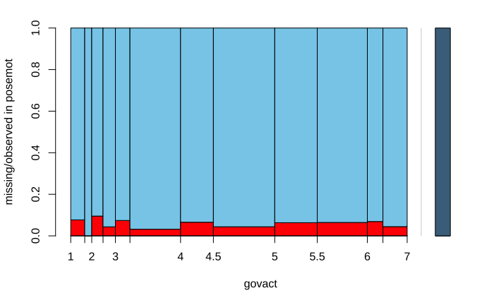

```r
spineMiss(globalWarm_train_m[, c("govact", "posemot")], miss.labels = FALSE)
```

# EDA: Correlations

10. Inspect the correlation matrix. Are there any highly correlated features? What about clusters of correlated features? Any features that are particularly correlated with the outcome?

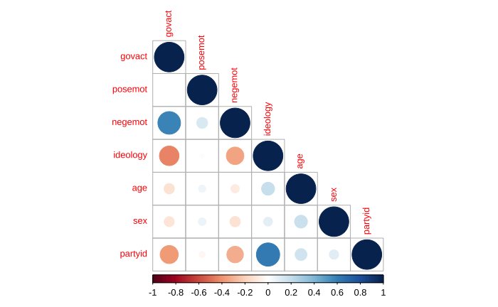

# EDA: Shape of relationships

12. Use a scatterplot matrix to examine the shape of relationships between features and the outcome variable. Do the relationships look linear or nonlinear?

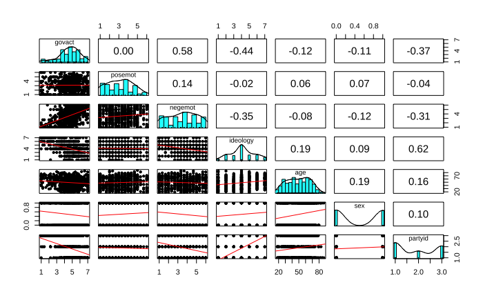

# Conclusions

13. In a few sentences, please describe what you learned about this dataset through these exploratory data analyses.
14. What are some ideas you have for using this knowledge to inform your feature engineering and modeling decisions?